# Weekly update for June 20

## Show and Tell June 20

## Grooves

- Check multiple spots on the land to see where the get_grooves_rollapply function is failing.

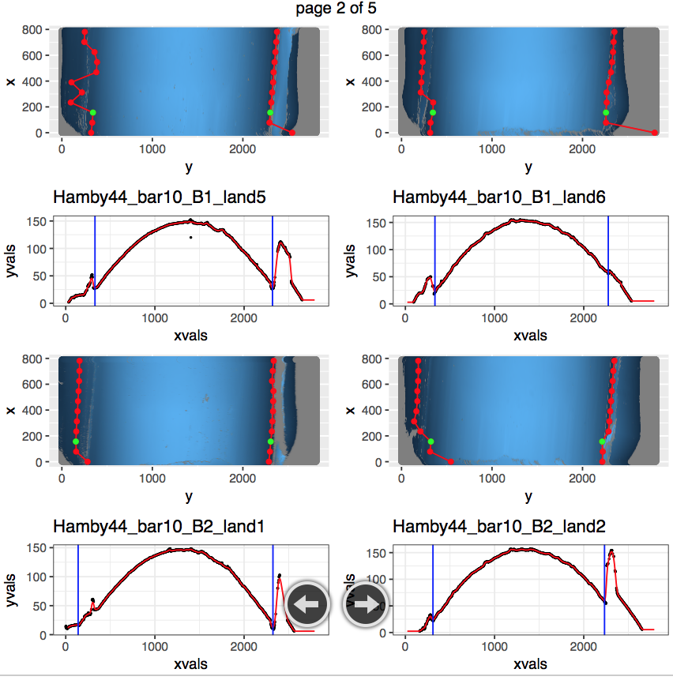

## Grooves

- These images are HUGE, so we will be downsampling the full land to save some of that space.
- Every 3rd x value will be kept
- If anyone has better suggestions for downsampling, please let us know!

## Grooves - now implementing

- Median instead of mean
- Single smoothing instead of double smoothing
- Testing different smoothing parameters - is it smoothing enough of the striations out?
- Still calculate edge values in smoothing that were previously cut off due to the smoothing window.
- These will each go in as a ‘method’ in forked `bulletr`, and updated with changes if any are promising.
- For each land we test, all of these methods will be plotted side-by-side.

## Shoeprints

- The plan is to have ready by Monday the image registry
- It require the assistance of the shiny app: https://github.com/CSAFE-ISU/solefinder-app
- Also, the shiny app will allow the user to see the image registry and get cross-sections